# Coding Assignment 3

Team 9

Due: 2024-12-07 23:59

A Florida health insurance company wants to predict annual claims for individual clients. The company pulls a random sample of 100 customers. The owner wishes to charge an actuarially fair premium to ensure a normal rate of return. The owner collects all of their current customer’s health care expenses from the last year and compares them with what is known about each customer’s plan.

The data on the 100 customers in the sample is as follows:

- Charges: Total medical expenses for a particular insurance plan (in dollars)
- Age: Age of the primary beneficiary
- BMI: Primary beneficiary’s body mass index (kg/m2)
- Female: Primary beneficiary’s birth sex (0 = Male, 1 = Female)
- Children: Number of children covered by health insurance plan (includes other dependents as well)
- Smoker: Indicator if primary beneficiary is a smoker (0 = non-smoker, 1 = smoker)
- Cities: Dummy variables for each city with the default being Sanford

Answer the following questions using complete sentences and attach all output, plots, etc. within this report.

```r
insurance <- read.csv("../CodingAssignment03/Insurance_Data_Group9.csv")
```

## Question 1

Randomly select 30 observations from the sample and exclude from all modeling. Provide the summary statistics (min, max, std, mean, median) of the quantitative variables for the 70 observations.

```r
set.seed(123457)
exclude <- sample(nrow(insurance), 30)
train <- insurance[-exclude, ]
test <- insurance[exclude, ]

train %>%
  select(Charges, Age, BMI, Children) %>%
  tbl_summary(statistic = list(all_continuous() ~ c("{mean}",       # Mean
                                                    "{sd}",         # Standard Deviation
                                                    "{median}",     # Median
                                                    "{min}",        # Minimum
                                                    "{max}"         # Maximum
                                                    )
                               ),
    type = all_continuous() ~ "continuous2" # Enhanced formatting for continuous variables
  )
```

| **Characteristic** | **N = 70**<sup>1</sup> |
| --- | --- |
| Charges |  |
| Mean | 13,375 |
| SD | 12,237 |
| Median | 9,570 |
| Min | 1,136 |
| Max | 51,195 |
| Age |  |
| Mean | 41 |
| SD | 14 |
| Median | 44 |
| Min | 18 |
| Max | 64 |
| BMI |  |
| Mean | 31.1 |
| SD | 5.7 |
| Median | 30.8 |
| Min | 16.0 |
| Max | 47.7 |
| Children |  |
| 0 | 27 (39%) |
| 1 | 15 (21%) |
| 2 | 16 (23%) |
| 3 | 9 (13%) |
| 4 | 2 (2.9%) |
| 5 | 1 (1.4%) |

<sup>1</sup> n (%)

## Question 2

Provide the correlation between all quantitative variables

```r
cor(train[, c("Charges", "Age", "BMI", "Children")])
```

```
##            Charges       Age       BMI  Children
## Charges  1.0000000 0.2669529 0.2394231 0.2497586
## Age      0.2669529 1.0000000 0.2372201 0.2987257
## BMI      0.2394231 0.2372201 1.0000000 0.1781634
## Children 0.2497586 0.2987257 0.1781634 1.0000000
```

## Question 3

Run a regression that includes all independent variables in the data table. Does the model above violate any of the Gauss-Markov assumptions? If so, what are they and what is the solution for correcting?

```r
allvar <- lm(Charges ~ Age + BMI + Female + Children + Smoker + WinterPark + WinterSprings + Oviedo, data = train)
summary(allvar)
```

```
##
## Call:
## lm(formula = Charges ~ Age + BMI + Female + Children + Smoker +
##     WinterPark + WinterSprings + Oviedo, data = train)
##
## Residuals:
##      Min       1Q   Median       3Q      Max
## -11292.8  -2542.3     18.9   3010.9  18364.1
##
## Coefficients:
##                Estimate Std. Error t value Pr(>|t|)
## (Intercept)   -15510.23    3872.49  -4.005 0.000171 ***
## Age              236.62      47.33   4.999 5.15e-06 ***
## BMI              457.04     117.63   3.886 0.000254 ***
## Female         -1722.18    1286.24  -1.339 0.185562
## Children        1401.17     546.30   2.565 0.012799 *
## Smoker         23987.60    1550.21  15.474  < 2e-16 ***
## WinterPark     -3948.67    1775.32  -2.224 0.029846 *
## WinterSprings   -382.03    1950.68  -0.196 0.845382
## Oviedo          -309.50    1913.52  -0.162 0.872042
## ---
## Signif. codes:  0 '***' 0.001 '**' 0.01 '*' 0.05 '.' 0.1 ' ' 1
##
## Residual standard error: 5074 on 61 degrees of freedom
## Multiple R-squared:  0.848,  Adjusted R-squared:  0.8281
## F-statistic: 42.54 on 8 and 61 DF,  p-value: < 2.2e-16
```

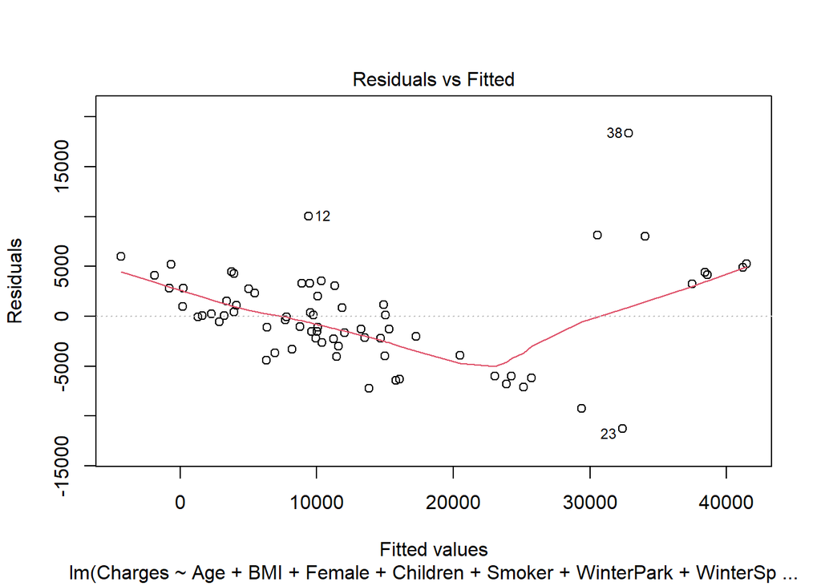

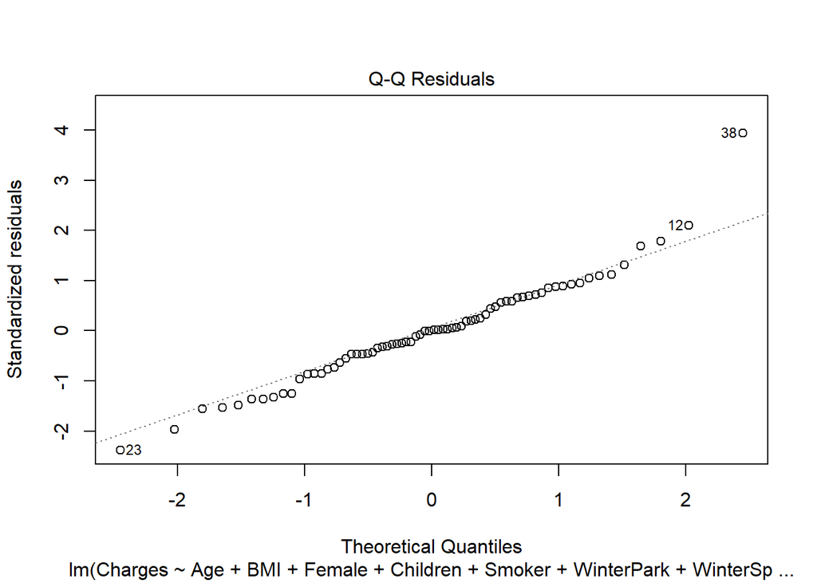

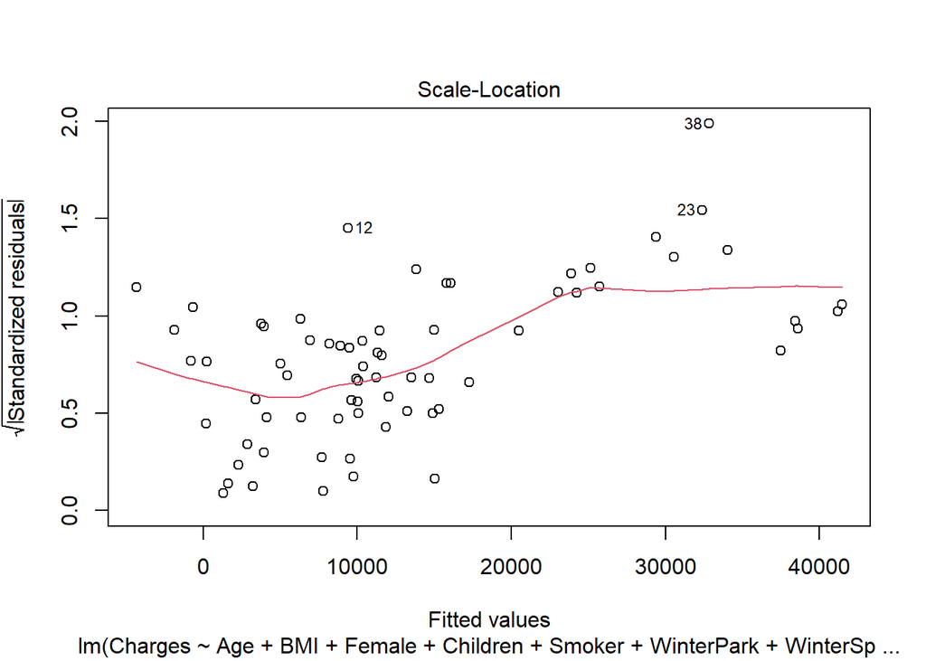

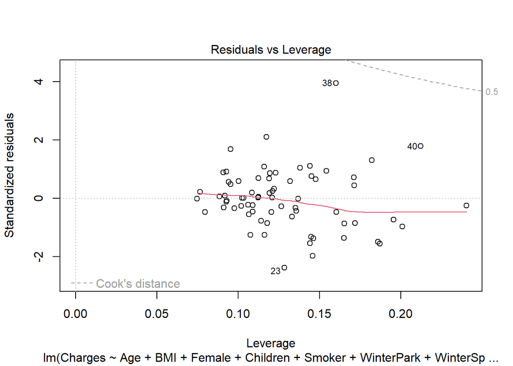

```r
plot(allvar)
```

Yes, the plots above show some of the Gauss-Markov assumptions have been violated.